# Práctico 10

Introducción a tidyverse

# Introducción

En el presente práctico se trabajará con librerías del conjunto **tidyverse**, las cuales permiten cargar, almacenar, filtrar, editar y visualizar datos de formato tabular. En particular, de las muchas librerías que engloba tidyverse nos focalizaremos en el uso de cuatro librerías clave: **readr**, **dplyr**, **tidyr** y **ggplot2**.

La modalidad será un práctico de tipo exposición, donde se irán discutiendo las operaciones realizadas. Se utilizarán dos sets de datos públicos obtenidos de (Data-Hub)[https://datahub.io/]. Los mismos son referentes a aeropuertos situados a lo largo del planeta.

Información rápida sobre las operaciones clásicas de estas librerías se encuentran en las llamadas **cheatsheets**. A continuación una lista con las mismas.

- [Cheatsheet de readr](https://evoldyn.gitlab.io/evomics-2018/ref-sheets/R_data-import.pdf)
- [Cheatsheet de dplyr + tidyr](https://rstudio.com/wp-content/uploads/2015/02/data-wrangling-cheatsheet.pdf)
- [Cheatsheet de ggplot2](https://rstudio.com/wp-content/uploads/2015/03/ggplot2-cheatsheet.pdf)

Varias cheatsheets se encuentran en [esta página de RStudio](https://rstudio.cloud/learn/cheat-sheets)

A su vez, se recomienda el [libro R para Ciencia de Datos](https://es.r4ds.hadley.nz/), escrito por el inventor de tidyverse (Hadley Wickham). En el mismo se expican de forma clara y concisa cómo utilizar la totalidad de estas herramientas.

# Práctico

## Leyendo datos con la librería **readr**

Es muy común que los archivos con los datos crudos que deseamos analizar se encuentren alojados en el disco duro en forma de tablas. Los mismos pueden estar en distintos formatos como CSV (*comma-separated values*), TSV (*tab-separated values*) u otros.

La librería **readr** posee funciones que permiten cargar estas tablas a R, produciendo automáticamente un objeto de clase *tibble*, específico de la librería tidyverse y diseñado para trabajar en ella. Las funciones de readr suelen llamarse **read_*()**.

```r
# cargo las librerias que utilizamos en el practico
library(magrittr)
library(tidyverse)

# cargo la tabla CSV
aeropuertos = readr::read_csv('airport-codes.csv')
# la visualizo
aeropuertos
```

```
## # A tibble: 55,113 x 12
##    ident type          name                               elevation_ft continent iso_country iso_region municipality gps_code iata_code local_code coordinates
##    <chr> <chr>         <chr>                                     <dbl> <chr>     <chr>       <chr>      <chr>        <chr>    <chr>     <chr>      <chr>
##  1 00A   heliport      Total Rf Heliport                            11 <NA>      US          US-PA      Bensalem     00A      <NA>      00A        40.07080078125, -74.93360137939453
##  2 00AA  small_airport Aero B Ranch Airport                       3435 <NA>      US          US-KS      Leoti        00AA     <NA>      00AA       38.704022, -101.473911
##  3 00AK  small_airport Lowell Field                                450 <NA>      US          US-AK      Anchor Point 00AK     <NA>      00AK       59.94919968, -151.695999146
##  4 00AL  small_airport Epps Airpark                                820 <NA>      US          US-AL      Harvest      00AL     <NA>      00AL       34.86479949951172, -86.77030181884766
##  5 00AR  closed        Newport Hospital & Clinic Heliport          237 <NA>      US          US-AR      Newport      <NA>     <NA>      <NA>       35.6087, -91.254898
##  6 00AS  small_airport Fulton Airport                             1100 <NA>      US          US-OK      Alex         00AS     <NA>      00AS       34.9428028, -97.8180194
##  7 00AZ  small_airport Cordes Airport                             3810 <NA>      US          US-AZ      Cordes       00AZ     <NA>      00AZ       34.305599212646484, -112.16500091552734
##  8 00CA  small_airport Goldstone /Gts/ Airport                    3038 <NA>      US          US-CA      Barstow      00CA     <NA>      00CA       35.350498199499995, -116.888000488
##  9 00CL  small_airport Williams Ag Airport                          87 <NA>      US          US-CA      Biggs        00CL     <NA>      00CL       39.427188, -121.763427
## 10 00CN  heliport      Kitchen Creek Helibase Heliport            3350 <NA>      US          US-CA      Pine Valley  00CN     <NA>      00CN       32.7273736, -116.4597417
## # … with 55,103 more rows
```

## Realizando modificaciones con la librería **tidyr**

Es común que tengamos que realizar operaciones sobre las tablas que nos disponemos a analizar. Estas pueden poseer una disposición poco amigable, o poseer celdas donde exista más de un tipo de variable a la vez. Las funciones de la librería **tidyr** nos permiten llevar nuestros datos al formato deseado para análisis con tidyverse. En inglés se denomina a este tipo de tablas *tidy data*.

```r
# realizo una modificacion con la libreria tidyr
aeropuertos %<>% tidyr::separate(data = ., col = 'coordinates', into = c('lon', 'lat'), sep = ', ')
aeropuertos$lat %<>% as.numeric()
aeropuertos$lon %<>% as.numeric()

# viasualizo el resultado
aeropuertos
```

```
## # A tibble: 55,113 x 13
##    ident type          name                               elevation_ft continent iso_country iso_region municipality gps_code iata_code local_code   lon    lat
##    <chr> <chr>         <chr>                                     <dbl> <chr>     <chr>       <chr>      <chr>        <chr>    <chr>     <chr>      <dbl>  <dbl>
##  1 00A   heliport      Total Rf Heliport                            11 <NA>      US          US-PA      Bensalem     00A      <NA>      00A         40.1  -74.9
##  2 00AA  small_airport Aero B Ranch Airport                       3435 <NA>      US          US-KS      Leoti        00AA     <NA>      00AA        38.7 -101.
##  3 00AK  small_airport Lowell Field                                450 <NA>      US          US-AK      Anchor Point 00AK     <NA>      00AK        59.9 -152.
##  4 00AL  small_airport Epps Airpark                                820 <NA>      US          US-AL      Harvest      00AL     <NA>      00AL        34.9  -86.8
##  5 00AR  closed        Newport Hospital & Clinic Heliport          237 <NA>      US          US-AR      Newport      <NA>     <NA>      <NA>        35.6  -91.3
##  6 00AS  small_airport Fulton Airport                             1100 <NA>      US          US-OK      Alex         00AS     <NA>      00AS        34.9  -97.8
##  7 00AZ  small_airport Cordes Airport                             3810 <NA>      US          US-AZ      Cordes       00AZ     <NA>      00AZ        34.3 -112.
##  8 00CA  small_airport Goldstone /Gts/ Airport                    3038 <NA>      US          US-CA      Barstow      00CA     <NA>      00CA        35.4 -117.
##  9 00CL  small_airport Williams Ag Airport                          87 <NA>      US          US-CA      Biggs        00CL     <NA>      00CL        39.4 -122.
## 10 00CN  heliport      Kitchen Creek Helibase Heliport            3350 <NA>      US          US-CA      Pine Valley  00CN     <NA>      00CN        32.7 -116.
## # … with 55,103 more rows
```

Aunque a simple vista no parezca, es posible que nuestra tabla posea datos faltantes en las columnas que posee. Podemos corroborar la existencia de datos faltantes utilizando la función **filter()**, de la librería **dplyr**. A su vez nos valdremos de la función **is.na()**.

```r
# visualizamos un caso en el cual existen NAs en nuestra tabla.
aeropuertos %>%
  filter(is.na(iso_country))
```

```
## # A tibble: 247 x 13
##    ident type           name                                      elevation_ft continent iso_country iso_region municipality gps_code iata_code local_code   lon   lat
##    <chr> <chr>          <chr>                                            <dbl> <chr>     <chr>       <chr>      <chr>        <chr>    <chr>     <chr>      <dbl> <dbl>
##  1 FYAA  small_airport  Ai-Ais Airport                                    2000 AF        <NA>        NA-KU      Ai-Ais       FYAA     AIW       <NA>       -28.0  17.6
##  2 FYAB  small_airport  Aroab B Airport                                   3235 AF        <NA>        NA-KA      Aroab        FYAB     <NA>      <NA>       -26.8  19.6
##  3 FYAK  small_airport  Aussenkehr Airport                                 970 AF        <NA>        NA-KA      Aussenkehr   FYAK     <NA>      <NA>       -28.5  17.5
##  4 FYAM  small_airport  Aminuis Airstrip                                  4012 AF        <NA>        NA-OH      Aminuis      FYAM     <NA>      <NA>       -23.7  19.4
##  5 FYAR  medium_airport Arandis Airport                                   1905 AF        <NA>        NA-ER      Arandis      FYAR     ADI       <NA>       -22.5  15.0
##  6 FYAS  small_airport  Aus Airport                                       4856 AF        <NA>        NA-KA      Aus          FYAS     <NA>      <NA>       -26.7  16.3
##  7 FYAV  small_airport  Ariamsvley Airport                                2549 AF        <NA>        NA-KA      Ariamsvley   FYAV     <NA>      <NA>       -28.1  19.8
##  8 FYBC  small_airport  Bethanien Airport                                 3260 AF        <NA>        NA-KA      Bethanien    FYBC     <NA>      <NA>       -26.5  17.2
##  9 FYBJ  small_airport  Bitterwasser Lodge & Flying Club Airfield         4167 AF        <NA>        NA-HA      Bitterwasser FYBJ     <NA>      <NA>       -23.9  18.0
## 10 FYEK  small_airport  Epukiro Airport                                   4892 AF        <NA>        NA-OH      Epukiro      FYEK     <NA>      <NA>       -21.8  19.1
## # … with 237 more rows
```

Nuestro *tibble* posee algunos valores NAs en la columna *continent*. Nos deshacemos de ella utilizando la función **select()** de la librería **dplyr**.

Nos valdremos de otra tabla, **country-and-continent-codes-list-csv.csv**, en la cual se correlacionan correctamente los aeropuertos y sus continentes. Esto nos servirá más adelante, ya que haremos algunos análisis categorizando en base a continentes.

Unimos estas tablas con la función **left_join** de la librería **dplyr**.

```r
paises_vs_continentes = read_csv('country-and-continent-codes-list-csv') %>% dplyr::select(Continent_Name, Two_Letter_Country_Code)
aeropuertos %>%
 left_join(x = ., y = paises_vs_continentes, by = c('iso_country' = 'Two_Letter_Country_Code')) %>%
 dplyr::select(-continent) -> aeropuertos

aeropuertos
```

```
## # A tibble: 56,524 x 13
##    ident type          name                               elevation_ft iso_country iso_region municipality gps_code iata_code local_code   lon    lat Continent_Name
##    <chr> <chr>         <chr>                                     <dbl> <chr>       <chr>      <chr>        <chr>    <chr>     <chr>      <dbl>  <dbl> <chr>
##  1 00A   heliport      Total Rf Heliport                            11 US          US-PA      Bensalem     00A      <NA>      00A         40.1  -74.9 North America
##  2 00AA  small_airport Aero B Ranch Airport                       3435 US          US-KS      Leoti        00AA     <NA>      00AA        38.7 -101.  North America
##  3 00AK  small_airport Lowell Field                                450 US          US-AK      Anchor Point 00AK     <NA>      00AK        59.9 -152.  North America
##  4 00AL  small_airport Epps Airpark                                820 US          US-AL      Harvest      00AL     <NA>      00AL        34.9  -86.8 North America
##  5 00AR  closed        Newport Hospital & Clinic Heliport          237 US          US-AR      Newport      <NA>     <NA>      <NA>        35.6  -91.3 North America
##  6 00AS  small_airport Fulton Airport                             1100 US          US-OK      Alex         00AS     <NA>      00AS        34.9  -97.8 North America
##  7 00AZ  small_airport Cordes Airport                             3810 US          US-AZ      Cordes       00AZ     <NA>      00AZ        34.3 -112.  North America
##  8 00CA  small_airport Goldstone /Gts/ Airport                    3038 US          US-CA      Barstow      00CA     <NA>      00CA        35.4 -117.  North America
##  9 00CL  small_airport Williams Ag Airport                          87 US          US-CA      Biggs        00CL     <NA>      00CL        39.4 -122.  North America
## 10 00CN  heliport      Kitchen Creek Helibase Heliport            3350 US          US-CA      Pine Valley  00CN     <NA>      00CN        32.7 -116.  North America
## # … with 56,514 more rows
```

## Obteniendo algunos valores descriptivos con funciones de la librería **dplyr**

Ahora que contamos con nuestra tabla completa, podemos obtener algunos valores descriptivos valiéndonos de las funciones **group_by()** y **summarise()**

Podríamos, por ejemplo, preguntarnos cuántos aeropuertos tenemos descritos por continente. Al realizar estas operaciones es necesario ser cuidadosos, ya que filas repetidas pueden distorsionar el estudio de las variables de interés.

```r
# analizamos el numero de aeropuertos por continente
aeropuertos %>%
  # seleccionamos columnas de interes
  dplyr::select(name, Continent_Name) %>%
  # nos deshacemos de filas repetidas
  unique() %>%
  # agrupamos segun valor en columna 'Continent_Name'
  group_by(Continent_Name) %>%
  # obtenemos el resumen
  summarise(numero_aeropuertos = n())
```

```
## # A tibble: 8 x 2
##   Continent_Name numero_aeropuertos
##   <chr>                       <int>
## 1 Africa                       3327
## 2 Antarctica                     31
## 3 Asia                         6016
## 4 Europe                       8298
## 5 North America               26063
## 6 Oceania                      3012
## 7 South America                7110
## 8 <NA>                            6
```

```r
# analizaremos el tipo de aeropuertos que hay por continente
aeropuertos %>%
  dplyr::select(name, Continent_Name, type) %>%
  unique() %>%
  # en este caso agrupamos segun dos columnas, 'Continent_Name' y 'type'
  group_by(Continent_Name, type) %>%
  summarise(numero_aeropuertos = n())
```

```
## # A tibble: 45 x 3
## # Groups:   Continent_Name [8]
##    Continent_Name type           numero_aeropuertos
##    <chr>          <chr>                       <int>
##  1 Africa         closed                         70
##  2 Africa         heliport                       10
##  3 Africa         large_airport                  47
##  4 Africa         medium_airport                448
##  5 Africa         seaplane_base                   1
##  6 Africa         small_airport                2757
##  7 Antarctica     closed                          2
##  8 Antarctica     medium_airport                  4
##  9 Antarctica     small_airport                  25
## 10 Asia           closed                        398
## # … with 35 more rows
```

```r
# veremos ahora la altura promedio de los aeropuertos por continente
aeropuertos %>%
  # nos deshacemos primero de aquellos aeropuertos para los que no tenemos datos
  filter(!is.na(elevation_ft)) %>%
  # seleccionamos columnas de interes
  dplyr::select(name, Continent_Name, iso_country, elevation_ft) %>%
  unique() %>%
  group_by(Continent_Name) %>%
  summarise(numero_aeropuertos = mean(elevation_ft))
```

```
## # A tibble: 8 x 2
##   Continent_Name numero_aeropuertos
##   <chr>                       <dbl>
## 1 Africa                      2583.
## 2 Antarctica                  1069.
## 3 Asia                        1207.
## 4 Europe                       785.
## 5 North America               1200.
## 6 Oceania                      901.
## 7 South America               1310.
## 8 <NA>                        1841
```

## Visualizando con la librería **ggplot2**

Visualizaremos ahora nuestro set de datos. Empezaremos graficando, tomando la variable **lon** como coordenada *x* de nuestro gráfico y la variable **lat** como coordenada *y*, especificando estos argumentos con la función **aes()** de la librería.

A su vez, debemos elegir una geometría que represente a nuestros puntos. En este caso, llamaremos a la función **geom_point()** para especificar que la misma será la geometría de puntos.

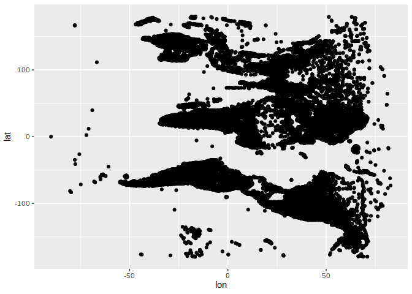

```r
# tomamos los datos de aeropuerto
aeropuertos %>%
  # seteamos las variables a representarse en de los ejes x e y,
  ggplot(data = .,
         mapping = aes(x = lon, y = lat)) +
  # seteamos el tipo de geometria  a ser usada ('point')
  geom_point()
```

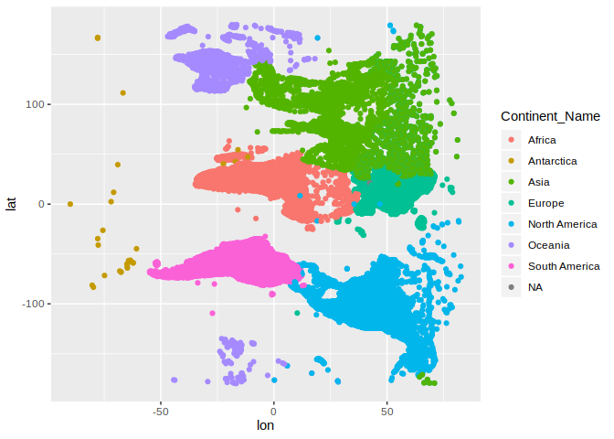

```r
# podemos a su vez colorear en funcion de la columna 'continente'
aeropuertos %>%
  ggplot(data = .,
         mapping = aes(x = lon, y = lat, color = Continent_Name)) +
  geom_point()
```

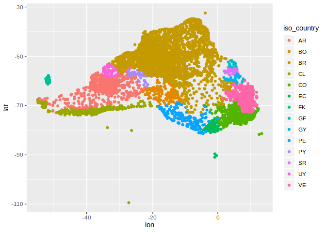

```r
# nos focalizaremos en America del Sur, coloreando segun pais
aeropuertos %>%
  dplyr::filter(., Continent_Name == 'South America') %>%
  ggplot(data = .,
         mapping = aes(x = lon, y = lat, color = iso_country)) +
  geom_point()
```

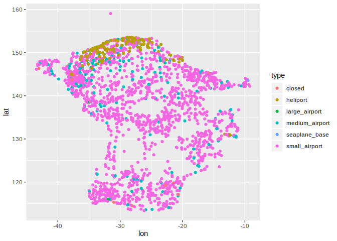

```r
# Filtraremos en base a un pais especifico, Australia (codigo AU). Coloreamos segun tipo de aeropuerto
aeropuertos %>%
  filter(iso_country == 'AU') %>%
  ggplot(data = ., mapping = aes(x = lon, y = lat, color = type)) + geom_point()
```

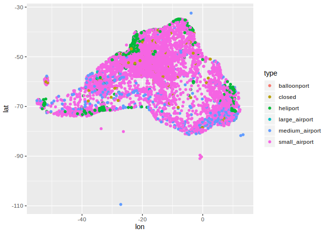

```r
# Observamos como se distribuye el tipo de aeropuertos en America del Sur.
aeropuertos %>%
  filter(Continent_Name == 'South America') %>%
  ggplot(data = ., mapping = aes(x = lon, y = lat, color = type)) + geom_point()
```

A su vez podriamos realizar un boxplot para visualizar la dispersión que posee cada continente en torno a esta variable. Para ello podemos utilizar la función **geom_boxplot()** para visualizar nuestras variables con esa geometría.

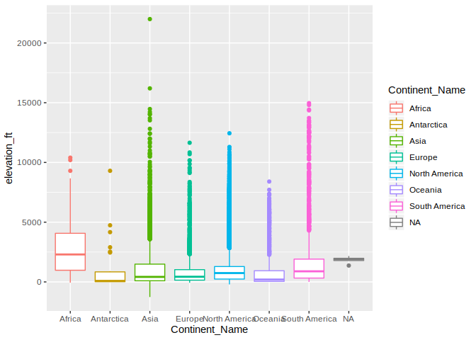

```r
aeropuertos %>%
  dplyr::filter(!is.na(elevation_ft)) %>%
  ggplot(data = .,
         mapping = aes(x = Continent_Name, y = elevation_ft, color = Continent_Name)) +
  # en este caso utilizamos una geometria de tipo 'boxplot'
  geom_boxplot()
```

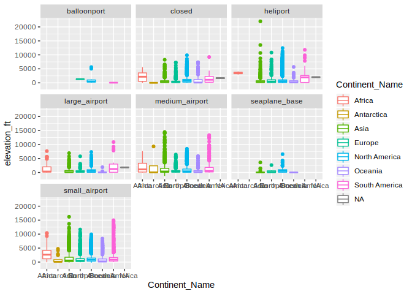

```r
aeropuertos %>%
  dplyr::filter(!is.na(elevation_ft)) %>%
  ggplot(data = .,
         mapping = aes(x = Continent_Name, y = elevation_ft, color = Continent_Name)) +
  geom_boxplot() +
  # realizamos una subdivision 'en funcion' (~) de la columna 'type'
  facet_wrap(~type)
```

# Un poco más de información

> En la mayoría de los casos los datos con los que se trabaja suelen ser importados de archivos alojados en disco duro.

> Las funciones alojadas en esta librería comienzan todas con el prefijo **read_***, acompañadas del formato de texto que son capaces de leer. Así, por ejemplo, read_csv() es la función de esta librería diseñada para cargar archivos de texto con formato csv.

> En general estas funciones también poseen una sintaxis similar, por lo que al aprenderse a utilizar una ya se posee el conocimiento para lograr cargar otros formatos.

[figure not shown]

> La librería tidyverse fue construída para trabajar sobre conjuntos de datos que poseen un formato en particular: estos datos son llamados *tidy data*.

> Para que un set sea caracterizado como *tidy data* debe poseer tres características que están interrelacionadas:

> • Cada variable debe estar representada en una columna

> • Cada observación debe estar representada en una fila

> • Cada valor debe estar alojado en una celda

> Esto no siempre se cumple en la vida cotidiana. Los *datos crudos* con los que solemos presentarnos suelen tener uno (o los dos) siguientes defectos que nos > impiden definirlos como *tidy datasets*:

> • Una variable puede estar siendo representada en más de una columna

> • Una observación puede estar representada en más de una fila

> Estos problemas pueden ser resueltos con las funciones de la librería **tidyr**. Como su nombre indica, esta librería tiene como objetivo generar *tidy datasets* > en R.

> Sus funciones más importantes son

> • **pivot_longer()**: hace a un dataset más *largo*, alojando valores que antes se encontraban en columnas en filas.

> • **pivot_wider()**: lo opuesto de pibot_longer(). Un dataset se hace más *ancho* al aumentar el número de columnas y disminuir el número de filas.

> • **separate()**: separa observaciones de una columna en varias columnas, al separar los valores de sus celdas según un separador.

> • **unite()**: lo opuesto de separate(). Se unen observaciones de diferentes columnas, utilizando para ello un caracter especificado.

> Cinco de las funciones de la librería **dplyr** permiten hacer un conjunto de operaciones que, en su conjunto, logran resolver la mayoría de los problemas relacionados con la manipulación de datos en un *tidy dataset*.

> Estas funciones son

> • **filter()**: filtra un *tibble* teniendo en cuenta condiciones lógicas que operan sobre sus columnas.

> • **arrange()**: ordena un *tibble* en base a los valores de una o más columnas

> • **select()**: selecciona/descarta columnas de un *tibble*.

> • **mutate()**: genera nuevas columnas en un *tibble* en base a operaciones ejecutadas sobre columnas preexistentes